# Bank Marketing Success Prediction

### MSCA 31008 Data Mining Principles

### Group 6

- Dharmi Gala, Jennifer Dongha Lee, Mia Song, Nicolas Ferreira, Saloni Khandelwal, Sunvid Aneja

# 1. Problem Statement

- Our project aims to increase subscription rates for a banking institution by predicting the success of direct marketing campaigns.
- We will analyze a large data set of customer interactions with a Portuguese bank, collected via phone calls, to identify the key factors that influence subscription rates.
- Using data mining techniques, we will develop a robust model to predict subscription rates with high accuracy.
- By optimizing marketing campaigns based on our findings, we can improve the banking institution's customer satisfaction and achieve our project objective.

# 2. Project Definition of Variables

# Data set

bank-additional-full.csv with all examples, ordered by date (from May 2008 to November 2010). The binary classification goal is to predict if the client will subscribe a bank term deposit (variable y).

- Number of Instances: 41188 for bank-additional-full.csv
- Number of Attributes: 20 + output attribute.

# Attribute information

## 1) Input variables:

### bank client data:

1. age (numeric)
2. job : type of job (categorical: "admin.","blue-collar","entrepreneur","housemaid","management","retired","self-employed","services","student","technician","unemployed","unknown")
3. marital : marital status (categorical: "divorced","married","single","unknown"; note: "divorced" means divorced or widowed)
4. education (categorical: "basic.4y","basic.6y","basic.9y","high.school","illiterate","professional.course","university.degree","unknown")
5. default: has credit in default? (categorical: "no","yes","unknown")
6. housing: has housing loan? (categorical: "no","yes","unknown")
7. loan: has personal loan? (categorical: "no","yes","unknown")

### related with the last contact of the current campaign:

1. contact: contact communication type (categorical: "cellular","telephone")
2. month: last contact month of year (categorical: "jan", "feb", "mar", ..., "nov", "dec")
3. day_of_week: last contact day of the week (categorical: "mon","tue","wed","thu","fri")
4. duration: last contact duration, in seconds (numeric).

### other attributes:

1. campaign: number of contacts performed during this campaign and for this client (numeric, includes last contact)
2. pdays: number of days that passed by after the client was last contacted from a previous campaign (numeric; 999 means client was not previously contacted)
3. previous: number of contacts performed before this campaign and for this client (numeric)
4. poutcome: outcome of the previous marketing campaign (categorical: "failure","nonexistent","success")

### social and economic context attributes

1. emp.var.rate: employment variation rate - quarterly indicator (numeric)
2. cons.price.idx: consumer price index - monthly indicator (numeric)
3. cons.conf.idx: consumer confidence index - monthly indicator (numeric)
4. euribor3m: euribor 3 month rate - daily indicator (numeric)
5. nr.employed: number of employees - quarterly indicator (numeric)

## 2) Output variable (desired target):

1. y - has the client subscribed a term deposit? (binary: "yes","no")

## 3) Missing Attribute Values

- There are several missing values in some categorical attributes, all coded with the "unknown" label. These missing values can be treated as a possible class label or using deletion or imputation techniques.

# 3. Data Exploration

### 3.1. Import Data and Necessary Packages

```python
import numpy as np
import pandas as pd
from scipy import stats
import matplotlib.pyplot as plt
import seaborn as sns
import warnings
from sklearn.model_selection import train_test_split
from sklearn.utils import resample
from imblearn.over_sampling import ADASYN
from imblearn.over_sampling import SMOTE
from sklearn.model_selection import cross_val_score
from sklearn.metrics import confusion_matrix, ConfusionMatrixDisplay
from sklearn.feature_selection import chi2
from sklearn.preprocessing import LabelEncoder
from sklearn.metrics import classification_report
from sklearn.cluster import KMeans
from sklearn.linear_model import LogisticRegression
from sklearn.svm import SVC, LinearSVC
from sklearn.neighbors import KNeighborsClassifier
from sklearn.tree import DecisionTreeClassifier
from sklearn.ensemble import RandomForestClassifier
from sklearn.naive_bayes import GaussianNB
from sklearn.linear_model import Perceptron, SGDClassifier
```

```python
# from google.colab import drive
# drive.mount('/content/drive')
```

```python
# # Read the 'bank-full.csv' file into a Pandas dataframe
# df = pd.read_csv('/content/drive/Shared drives/DMP Project/Dataset/bank-additional/bank-additional-full.csv', sep=';')
```

```python
#importing the dataset
df = pd.read_csv('bank-additional/bank-additional-full.csv', delimiter=';')
df.head()
```

|  | age | job | marital | education | default | housing | loan | contact | month | day_of_week | ... | campaign | pdays | previous | poutcome | emp.var.rate | cons.price.idx | cons.conf.idx | euribor3m | nr.employed | y |
| --- | --- | --- | --- | --- | --- | --- | --- | --- | --- | --- | --- | --- | --- | --- | --- | --- | --- | --- | --- | --- | --- |
| 0 | 56 | housemaid | married | basic.4y | no | no | no | telephone | may | mon | ... | 1 | 999 | 0 | nonexistent | 1.1 | 93.994 | -36.4 | 4.857 | 5191.0 | no |
| 1 | 57 | services | married | high.school | unknown | no | no | telephone | may | mon | ... | 1 | 999 | 0 | nonexistent | 1.1 | 93.994 | -36.4 | 4.857 | 5191.0 | no |
| 2 | 37 | services | married | high.school | no | yes | no | telephone | may | mon | ... | 1 | 999 | 0 | nonexistent | 1.1 | 93.994 | -36.4 | 4.857 | 5191.0 | no |
| 3 | 40 | admin. | married | basic.6y | no | no | no | telephone | may | mon | ... | 1 | 999 | 0 | nonexistent | 1.1 | 93.994 | -36.4 | 4.857 | 5191.0 | no |
| 4 | 56 | services | married | high.school | no | no | yes | telephone | may | mon | ... | 1 | 999 | 0 | nonexistent | 1.1 | 93.994 | -36.4 | 4.857 | 5191.0 | no |

5 rows × 21 columns

### 3.2. Start EDA Process

```python
df.head()
```

|  | age | job | marital | education | default | housing | loan | contact | month | day_of_week | ... | campaign | pdays | previous | poutcome | emp.var.rate | cons.price.idx | cons.conf.idx | euribor3m | nr.employed | y |
| --- | --- | --- | --- | --- | --- | --- | --- | --- | --- | --- | --- | --- | --- | --- | --- | --- | --- | --- | --- | --- | --- |
| 0 | 56 | housemaid | married | basic.4y | no | no | no | telephone | may | mon | ... | 1 | 999 | 0 | nonexistent | 1.1 | 93.994 | -36.4 | 4.857 | 5191.0 | no |
| 1 | 57 | services | married | high.school | unknown | no | no | telephone | may | mon | ... | 1 | 999 | 0 | nonexistent | 1.1 | 93.994 | -36.4 | 4.857 | 5191.0 | no |
| 2 | 37 | services | married | high.school | no | yes | no | telephone | may | mon | ... | 1 | 999 | 0 | nonexistent | 1.1 | 93.994 | -36.4 | 4.857 | 5191.0 | no |
| 3 | 40 | admin. | married | basic.6y | no | no | no | telephone | may | mon | ... | 1 | 999 | 0 | nonexistent | 1.1 | 93.994 | -36.4 | 4.857 | 5191.0 | no |
| 4 | 56 | services | married | high.school | no | no | yes | telephone | may | mon | ... | 1 | 999 | 0 | nonexistent | 1.1 | 93.994 | -36.4 | 4.857 | 5191.0 | no |

5 rows × 21 columns

We will first examine the overall structure to understand our data and gain ideas for future analysis.

```python
df.isnull().sum()
```

```
age               0
job               0
marital           0
education         0
default           0
housing           0
loan              0
contact           0
month             0
day_of_week       0
duration          0
campaign          0
pdays             0
previous          0
poutcome          0
emp.var.rate      0
cons.price.idx    0
cons.conf.idx     0
euribor3m         0
nr.employed       0
y                 0
dtype: int64
```

```python
df.head()
```

|  | age | job | marital | education | default | housing | loan | contact | month | day_of_week | ... | campaign | pdays | previous | poutcome | emp.var.rate | cons.price.idx | cons.conf.idx | euribor3m | nr.employed | y |
| --- | --- | --- | --- | --- | --- | --- | --- | --- | --- | --- | --- | --- | --- | --- | --- | --- | --- | --- | --- | --- | --- |
| 0 | 56 | housemaid | married | basic.4y | no | no | no | telephone | may | mon | ... | 1 | 999 | 0 | nonexistent | 1.1 | 93.994 | -36.4 | 4.857 | 5191.0 | no |
| 1 | 57 | services | married | high.school | unknown | no | no | telephone | may | mon | ... | 1 | 999 | 0 | nonexistent | 1.1 | 93.994 | -36.4 | 4.857 | 5191.0 | no |
| 2 | 37 | services | married | high.school | no | yes | no | telephone | may | mon | ... | 1 | 999 | 0 | nonexistent | 1.1 | 93.994 | -36.4 | 4.857 | 5191.0 | no |
| 3 | 40 | admin. | married | basic.6y | no | no | no | telephone | may | mon | ... | 1 | 999 | 0 | nonexistent | 1.1 | 93.994 | -36.4 | 4.857 | 5191.0 | no |
| 4 | 56 | services | married | high.school | no | no | yes | telephone | may | mon | ... | 1 | 999 | 0 | nonexistent | 1.1 | 93.994 | -36.4 | 4.857 | 5191.0 | no |

5 rows × 21 columns

```python
df.info()
```

```
<class 'pandas.core.frame.DataFrame'>
RangeIndex: 41188 entries, 0 to 41187
Data columns (total 21 columns):
 #   Column          Non-Null Count  Dtype
---  ------          --------------  -----
 0   age             41188 non-null  int64
 1   job             41188 non-null  object
 2   marital         41188 non-null  object
 3   education       41188 non-null  object
 4   default         41188 non-null  object
 5   housing         41188 non-null  object
 6   loan            41188 non-null  object
 7   contact         41188 non-null  object
 8   month           41188 non-null  object
 9   day_of_week     41188 non-null  object
 10  duration        41188 non-null  int64
 11  campaign        41188 non-null  int64
 12  pdays           41188 non-null  int64
 13  previous        41188 non-null  int64
 14  poutcome        41188 non-null  object
 15  emp.var.rate    41188 non-null  float64
 16  cons.price.idx  41188 non-null  float64
 17  cons.conf.idx   41188 non-null  float64
 18  euribor3m       41188 non-null  float64
 19  nr.employed     41188 non-null  float64
 20  y               41188 non-null  object
dtypes: float64(5), int64(5), object(11)
memory usage: 6.6+ MB
```

```python
df.describe(include="all")
```

|  | age | job | marital | education | default | housing | loan | contact | month | day_of_week | ... | campaign | pdays | previous | poutcome | emp.var.rate | cons.price.idx | cons.conf.idx | euribor3m | nr.employed | y |
| --- | --- | --- | --- | --- | --- | --- | --- | --- | --- | --- | --- | --- | --- | --- | --- | --- | --- | --- | --- | --- | --- |
| count | 41188.00000 | 41188 | 41188 | 41188 | 41188 | 41188 | 41188 | 41188 | 41188 | 41188 | ... | 41188.000000 | 41188.000000 | 41188.000000 | 41188 | 41188.000000 | 41188.000000 | 41188.000000 | 41188.000000 | 41188.000000 | 41188 |
| unique | NaN | 12 | 4 | 8 | 3 | 3 | 3 | 2 | 10 | 5 | ... | NaN | NaN | NaN | 3 | NaN | NaN | NaN | NaN | NaN | 2 |
| top | NaN | admin. | married | university.degree | no | yes | no | cellular | may | thu | ... | NaN | NaN | NaN | nonexistent | NaN | NaN | NaN | NaN | NaN | no |
| freq | NaN | 10422 | 24928 | 12168 | 32588 | 21576 | 33950 | 26144 | 13769 | 8623 | ... | NaN | NaN | NaN | 35563 | NaN | NaN | NaN | NaN | NaN | 36548 |
| mean | 40.02406 | NaN | NaN | NaN | NaN | NaN | NaN | NaN | NaN | NaN | ... | 2.567593 | 962.475454 | 0.172963 | NaN | 0.081886 | 93.575664 | -40.502600 | 3.621291 | 5167.035911 | NaN |
| std | 10.42125 | NaN | NaN | NaN | NaN | NaN | NaN | NaN | NaN | NaN | ... | 2.770014 | 186.910907 | 0.494901 | NaN | 1.570960 | 0.578840 | 4.628198 | 1.734447 | 72.251528 | NaN |
| min | 17.00000 | NaN | NaN | NaN | NaN | NaN | NaN | NaN | NaN | NaN | ... | 1.000000 | 0.000000 | 0.000000 | NaN | -3.400000 | 92.201000 | -50.800000 | 0.634000 | 4963.600000 | NaN |
| 25% | 32.00000 | NaN | NaN | NaN | NaN | NaN | NaN | NaN | NaN | NaN | ... | 1.000000 | 999.000000 | 0.000000 | NaN | -1.800000 | 93.075000 | -42.700000 | 1.344000 | 5099.100000 | NaN |
| 50% | 38.00000 | NaN | NaN | NaN | NaN | NaN | NaN | NaN | NaN | NaN | ... | 2.000000 | 999.000000 | 0.000000 | NaN | 1.100000 | 93.749000 | -41.800000 | 4.857000 | 5191.000000 | NaN |
| 75% | 47.00000 | NaN | NaN | NaN | NaN | NaN | NaN | NaN | NaN | NaN | ... | 3.000000 | 999.000000 | 0.000000 | NaN | 1.400000 | 93.994000 | -36.400000 | 4.961000 | 5228.100000 | NaN |
| max | 98.00000 | NaN | NaN | NaN | NaN | NaN | NaN | NaN | NaN | NaN | ... | 56.000000 | 999.000000 | 7.000000 | NaN | 1.400000 | 94.767000 | -26.900000 | 5.045000 | 5228.100000 | NaN |

11 rows × 21 columns

We will divide our features into three categories based on the data types: numerical, categorical variables, and the target variable.

```python
col_names = []

for names in df.columns:
    col_names.append(names)

col_names
```

```
['age',
 'job',
 'marital',
 'education',
 'default',
 'housing',
 'loan',
 'contact',
 'month',
 'day_of_week',
 'duration',
 'campaign',
 'pdays',
 'previous',
 'poutcome',
 'emp.var.rate',
 'cons.price.idx',
 'cons.conf.idx',
 'euribor3m',
 'nr.employed',
 'y']
```

```python
def column_types(df):
  '''
  Identifies numerical and categorical columns in a pandas DataFrame and saves their column names in separate lists.

  Parameters
  ----------
  df : pandas DataFrame
      The DataFrame to identify numerical and categorical columns in.

  Returns
  -------
  tuple
      A tuple of two lists, where the first list contains the names of numerical columns and the second list
      contains the names of categorical columns.
  '''
  # identify numerical columns and save their names in a list
  num_cols = list(df.select_dtypes(include=['int64', 'float64']).columns)

  # identify categorical columns and save their names in a list
  cat_cols = list(df.select_dtypes(include=['object']).columns)

  return num_cols, cat_cols
```

```python
int_names, cat_names = column_types(df)
target_name = ['y']
```

```python
int_names
```

```
['age',
 'duration',
 'campaign',
 'pdays',
 'previous',
 'emp.var.rate',
 'cons.price.idx',
 'cons.conf.idx',
 'euribor3m',
 'nr.employed']
```

```python
cat_names
```

```
['job',
 'marital',
 'education',
 'default',
 'housing',
 'loan',
 'contact',
 'month',
 'day_of_week',
 'poutcome',
 'y']
```

```python
target_name
```

```
['y']
```

We examine unique values to see our data's overall structure and find any necessary outliers and anomalies to manage.

```python
for name in col_names:
    print('Column Name:', name)
    print('Unique Values:', df[name].unique())
    print('Unique Value #:', len(df[name].unique()))
    print('')
```

```
Column Name: age
Unique Values: [56 57 37 40 45 59 41 24 25 29 35 54 46 50 39 30 55 49 34 52 58 32 38 44
 42 60 53 47 51 48 33 31 43 36 28 27 26 22 23 20 21 61 19 18 70 66 76 67
 73 88 95 77 68 75 63 80 62 65 72 82 64 71 69 78 85 79 83 81 74 17 87 91
 86 98 94 84 92 89]
Unique Value #: 78

Column Name: job
Unique Values: ['housemaid' 'services' 'admin.' 'blue-collar' 'technician' 'retired'
 'management' 'unemployed' 'self-employed' 'unknown' 'entrepreneur'
 'student']
Unique Value #: 12

Column Name: marital
Unique Values: ['married' 'single' 'divorced' 'unknown']
Unique Value #: 4

Column Name: education
Unique Values: ['basic.4y' 'high.school' 'basic.6y' 'basic.9y' 'professional.course'
 'unknown' 'university.degree' 'illiterate']
Unique Value #: 8

Column Name: default
Unique Values: ['no' 'unknown' 'yes']
Unique Value #: 3

Column Name: housing
Unique Values: ['no' 'yes' 'unknown']
Unique Value #: 3

Column Name: loan
Unique Values: ['no' 'yes' 'unknown']
Unique Value #: 3

Column Name: contact
Unique Values: ['telephone' 'cellular']
Unique Value #: 2

Column Name: month
Unique Values: ['may' 'jun' 'jul' 'aug' 'oct' 'nov' 'dec' 'mar' 'apr' 'sep']
```

[output cut: 67 more lines]

```
 0.84  0.846 0.87  0.876 0.885 0.889 0.893 0.896 0.898 0.9   0.904 0.905
 0.895 0.894 0.891 0.89  0.888 0.886 0.882 0.88  0.878 0.877 0.942 0.953
 0.956 0.959 0.965 0.972 0.977 0.982 0.985 0.987 0.993 1.    1.008 1.016
 1.025 1.032 1.037 1.043 1.045 1.047 1.05  1.049 1.046 1.041 1.04  1.039
 1.035 1.03  1.031 1.028]
Unique Value #: 316

Column Name: nr.employed
Unique Values: [5191.  5228.1 5195.8 5176.3 5099.1 5076.2 5017.5 5023.5 5008.7 4991.6
 4963.6]
Unique Value #: 11

Column Name: y
Unique Values: ['no' 'yes']
Unique Value #: 2
```

```python
df['y'] = np.where(df['y'] == 'no', 0, 1)
```

As mentioned in the feature description, this data set has no null values, but values are categorized as 'unknown.' Rather than impute the 'unknown' values, we decide to consider them as one of the traits of our data.

```python
print('poutcome:', (df['poutcome'] == 'nonexistent').sum() / len(df) * 100, '%')
```

```
poutcome: 86.3431096435855 %
```

```python
feature_with_unknown = ['job', 'marital', 'default', 'housing', 'loan']

for feature in feature_with_unknown:
    unknown_obs = (df[feature] == 'unknown').sum()
    total_obs = len(df)
    print(feature, 'unknown_ratio:', unknown_obs / total_obs * 100, '%')
```

```
job unknown_ratio: 0.8012042342429834 %
marital unknown_ratio: 0.1942313295134505 %
default unknown_ratio: 20.87258424783918 %
housing unknown_ratio: 2.40361270272895 %
loan unknown_ratio: 2.40361270272895 %
```

We create a pair plot to better understand our data before analysis by visualizing correlations and identifying distinct patterns or outliers.

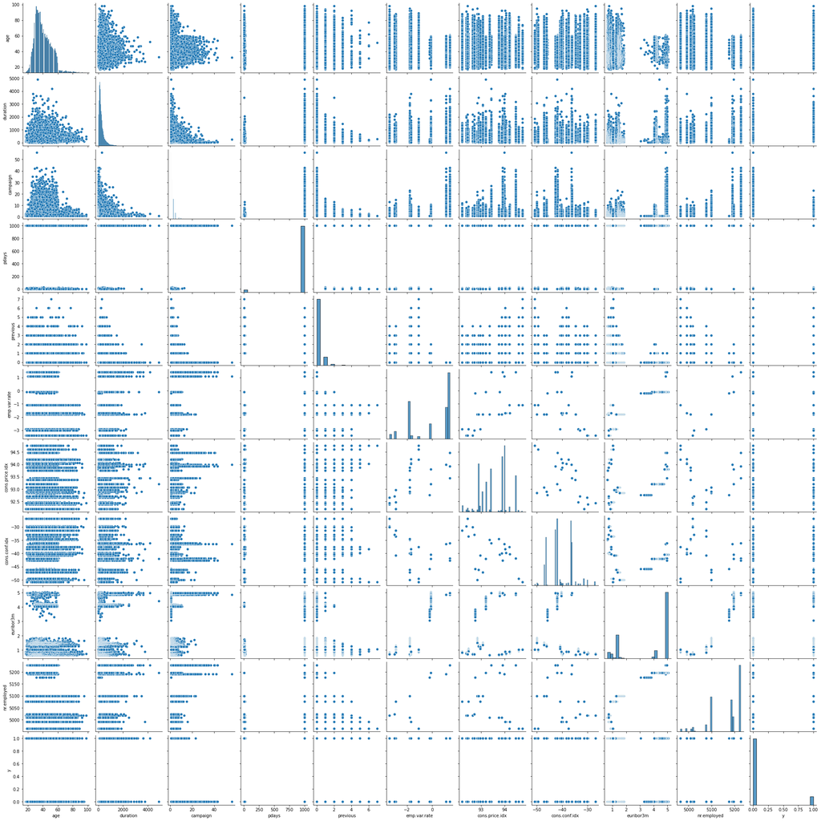

```python
sns.pairplot(df)
```

We will create basic plots using all features in our data set to explore further and understand our data. In the case of numerical variables, we generate distribution plots, and for our categorical variables, we create count plots.

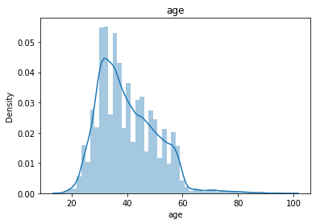

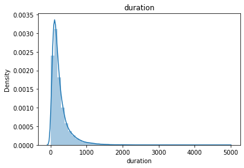

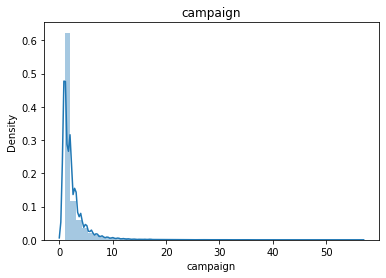

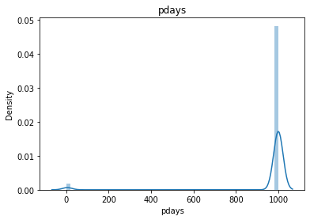

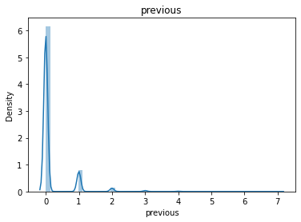

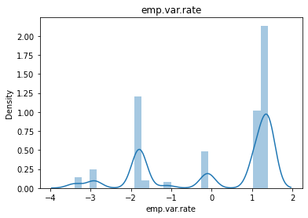

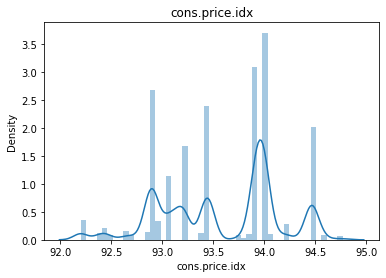

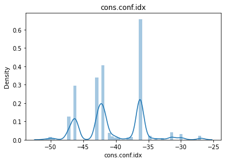

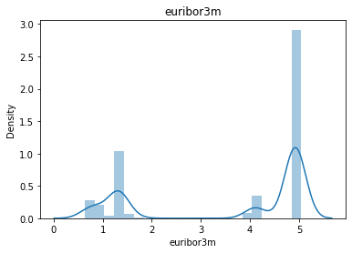

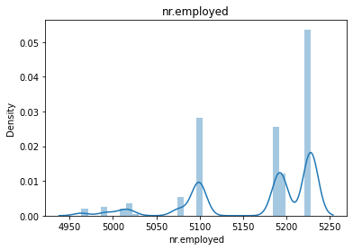

```python
for name in int_names:
    sns.distplot(df[name])
    plt.title(name)
    plt.show()
```

Note that the majority of values in pdays is 999, which indicates that one customer has never been contacted with the marketing purpose before, according to the feature description.

```python
df['pdays'].value_counts(ascending = False)
```

```
999    39673
3        439
6        412
4        118
9         64
2         61
7         60
12        58
10        52
5         46
13        36
11        28
1         26
15        24
14        20
8         18
0         15
16        11
17         8
18         7
22         3
19         3
21         2
25         1
26         1
27         1
20         1
Name: pdays, dtype: int64
```

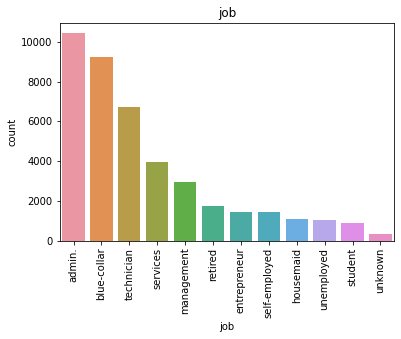

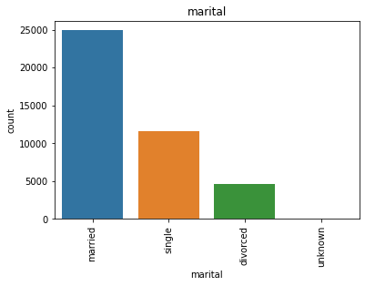

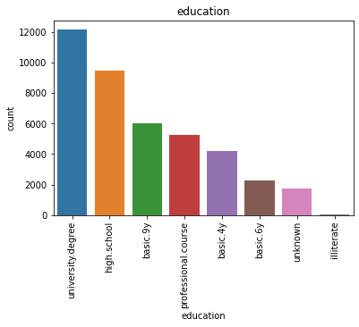

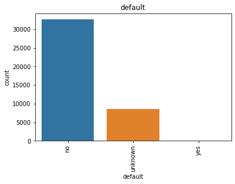

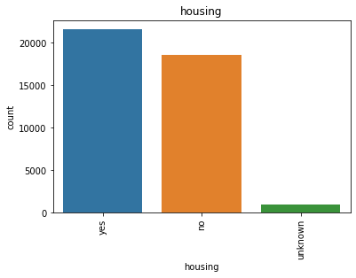

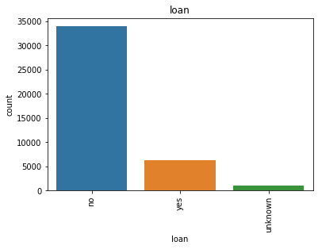

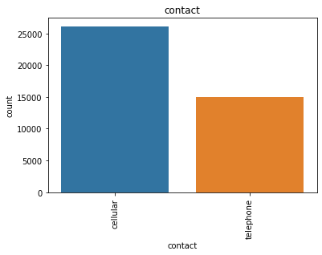

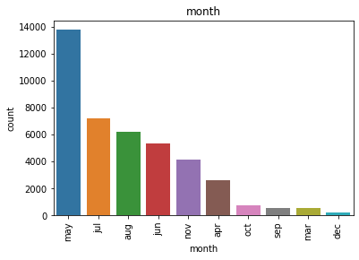

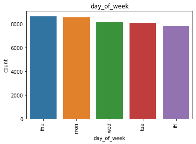

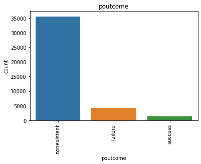

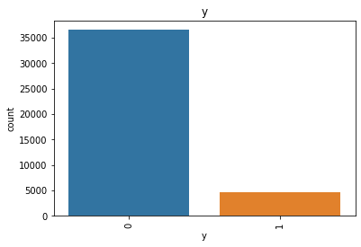

```python
for name in cat_names:
    sns.countplot(x=name, data=df, order=df[name].value_counts().index[::1])
    plt.xticks(rotation=90)
    plt.title(name)
    plt.show()
```

We will add one more layer to the created plot to see how the particular feature relates to the target variable 'y' that indicates whether our customer subscribed to the deposit service through tele marketing.

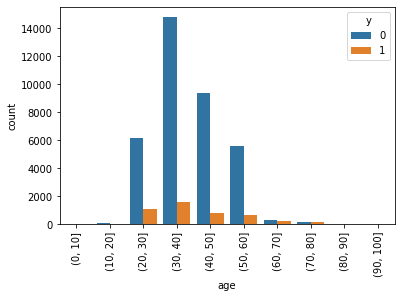

```python
age_groups = pd.cut(df.age, bins=range(0, 110, 10))

sns.countplot(x=age_groups, hue="y", data=df)
plt.xticks(rotation=90)
plt.show()
```

```python
df['y'].groupby(age_groups).sum() / df['y'].groupby(age_groups).count() * 100
```

```
age
(0, 10]            NaN
(10, 20]     40.714286
(20, 30]     14.731465
(30, 40]      9.746720
(40, 50]      8.173828
(50, 60]     10.653907
(60, 70]     43.442623
(70, 80]     47.194719
(80, 90]     49.541284
(90, 100]    50.000000
Name: y, dtype: float64
```

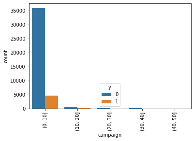

```python
campaign_groups = pd.cut(df.campaign, bins=range(0, 60, 10))
sns.countplot(x=campaign_groups, hue="y", data=df)
plt.xticks(rotation=90)
plt.show()
```

```python
df['y'].groupby(campaign_groups).sum() / df['y'].groupby(campaign_groups).count() * 100
```

```
campaign
(0, 10]     11.441256
(10, 20]     3.651685
(20, 30]     0.806452
(30, 40]     0.000000
(40, 50]     0.000000
Name: y, dtype: float64
```

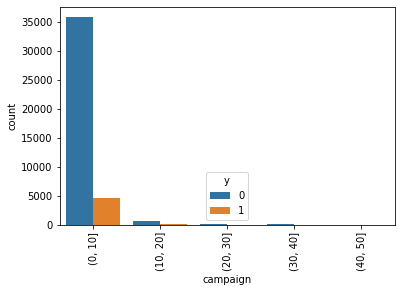

```python
previous_groups = pd.cut(df.campaign, bins=range(0, 60, 10))
sns.countplot(x=previous_groups, hue="y", data=df)
plt.xticks(rotation=90)
plt.show()
```

```python
df['y'].groupby(previous_groups).sum() / df['y'].groupby(previous_groups).count() * 100
```

```
campaign
(0, 10]     11.441256
(10, 20]     3.651685
(20, 30]     0.806452
(30, 40]     0.000000
(40, 50]     0.000000
Name: y, dtype: float64
```

Now, we start to explore our categorical variables with an added layer that results from our target variable.

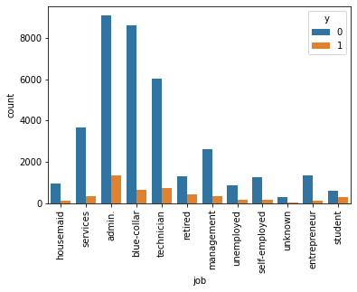

```python
sns.countplot(x='job', hue='y', data=df)

plt.xticks(rotation=90)

plt.show()
```